# Estatística no R

## Regressão logística

A regressão logística é mais apropriada quando se quer predizer uma variável dicotômica, ou as chances de que uma de duas categorias ocorram. Por exemplo, predizer a existência de certa condição mental (sim ou não), ser aprovado numa prova (sim ou não), ser parte do grupo experimental de uma investigação (sim ou não), entre outras. A regressão logística modela os dados por meio de uma curva sigmóide, em forma de S. Vejamos.

### Pacotes necessários

```r
pacman::p_load(dplyr,car,MASS,DescTools,QuantPsyc,ggplot2)
```

Para fazer a análise, usaremos o banco de dados rwas. Abaixo estão os códigos para as transformações das variáveis.

```r
# criar arquivo para teste das análises

rwas$education <- as.factor(rwas$education)
levels(rwas$education) <- c(NA,"Less than high school","High school","University degree","Graduate degree")

rwas$urban <- as.factor(rwas$urban)
levels(rwas$urban) <- c(NA,"Rural (country side)","Suburban","Urban (town, city)")
count(rwas,urban)
```

```
##                  urban    n
## 1 Rural (country side) 2082
## 2             Suburban 4370
## 3   Urban (town, city) 3316
## 4                 <NA>  113
```

```r
rwas$gender <- as.factor(rwas$gender)
levels(rwas$gender) <- c(NA,"Male","Female","Other")
count(rwas,gender)
```

```
##   gender    n
## 1   Male 6241
## 2 Female 3426
## 3  Other  195
## 4   <NA>   19
```

```r
expss::recode(rwas$engnat) <- c(0~NA,1~1,2~0)
rwas$engnat <- as.factor(rwas$engnat)
levels(rwas$engnat) <- c("No","Yes",NA)
count(rwas,engnat)
```

```
##   engnat    n
## 1     No 2517
## 2    Yes 7338
## 3   <NA>   26
```

```r
# count(rwas,age) %>% knitr::kable()
rwas$age[rwas$age > 100] <- NA

rwas$religion <- as.factor(rwas$religion)
levels(rwas$religion) <- c(NA,"Agnostic","Atheist","Buddhist","Christian (Catholic)","Christian (Mormon)",
                            "Christian (Protestant)","Christian (Other)","Hindu","Jewish","Muslim","Sikh","Other")
count(rwas,religion)
```

```
##                  religion    n
## 1                Agnostic 2284
## 2                 Atheist 3486
## 3                Buddhist  154
## 4    Christian (Catholic)  941
## 5      Christian (Mormon)   81
## 6  Christian (Protestant) 1021
## 7       Christian (Other)  664
## 8                   Hindu   61
## 9                  Jewish  136
## 10                 Muslim  149
## 11                   Sikh    6
## 12                  Other  827
## 13                   <NA>   71
```

```r
rwas$orientation <- as.factor(rwas$orientation)
levels(rwas$orientation) <- c(NA,"Heterosexual","Arab","Black","Indigenous Australian","Native American or White","Other")
count(rwas,orientation)
```

```
##                orientation    n
## 1             Heterosexual 7538
## 2                     Arab 1104
## 3                    Black  552
## 4    Indigenous Australian  277
## 5 Native American or White  313
## 6                     <NA>   97
```

```r
rwas$race <- as.factor(rwas$race)
levels(rwas$race) <- c(NA,"Asian","Bisexual","Homosexual","Asexual","Other")
count(rwas,race)
```

```
##         race    n
## 1      Asian  568
## 2   Bisexual   40
## 3 Homosexual  180
## 4    Asexual 8218
## 5      Other  771
## 6       <NA>  104
```

```r
expss::recode(rwas$voted) <- c(0~NA,1~1,2~0)
rwas$voted <- as.factor(rwas$voted)
levels(rwas$voted) <- c("No","Yes",NA)
count(rwas,voted)
```

```
##   voted    n
## 1    No 5538
## 2   Yes 4237
## 3  <NA>  106
```

```r
rwas$married <- as.factor(rwas$married)
levels(rwas$married) <- c(NA,"Never married","Currently married","Previously married")
count(rwas,married)
```

```
##              married    n
## 1      Never married 6741
## 2  Currently married 2430
## 3 Previously married  671
## 4               <NA>   39
```

```r
glimpse(rwas)
```

```
## Rows: 9,881
## Columns: 97
## $ Q1             <int> 4, 3, 1, 1, 1, 3, 1, 5, 2, 3, 3, 4, 1, 3, 2, 4, 2, 1, 4~
## $ Q2             <int> 1, 2, 6, 1, 1, 2, 1, 2, 1, 1, 1, 1, 1, 1, 1, 1, 1, 1, 7~
## $ Q3             <int> 1, 1, 7, 1, 1, 2, 1, 2, 1, 8, 1, 2, 1, 1, 1, 2, 1, 1, 5~
## $ Q4             <int> 9, 8, 9, 8, 3, 8, 9, 8, 9, 9, 9, 9, 9, 8, 4, 9, 9, 9, 7~
## $ Q5             <int> 3, 2, 3, 1, 1, 3, 1, 3, 1, 1, 1, 2, 1, 1, 5, 1, 1, 2, 4~
## $ Q6             <int> 9, 7, 9, 8, 9, 8, 5, 8, 9, 9, 9, 9, 9, 9, 4, 9, 9, 9, 6~
## $ Q7             <int> 2, 1, 9, 1, 1, 1, 1, 2, 1, 2, 1, 2, 1, 1, 1, 1, 1, 2, 5~
## $ Q8             <int> 7, 8, 4, 9, 1, 8, 9, 8, 9, 9, 4, 5, 8, 5, 1, 5, 6, 9, 6~
## $ Q9             <int> 8, 9, 9, 9, 7, 2, 9, 9, 9, 8, 9, 6, 8, 9, 1, 8, 9, 9, 5~
## $ Q10            <int> 1, 3, 9, 1, 1, 9, 1, 2, 2, 2, 1, 2, 1, 1, 8, 2, 5, 1, 6~
## $ Q11            <int> 9, 7, 8, 9, 9, 8, 9, 8, 9, 9, 9, 8, 9, 9, 3, 9, 9, 9, 8~
## $ Q12            <int> 1, 5, 9, 2, 2, 2, 1, 3, 1, 1, 1, 2, 3, 1, 7, 2, 2, 1, 6~
## $ Q13            <int> 9, 9, 9, 8, 9, 5, 9, 2, 9, 9, 9, 8, 8, 9, 2, 8, 9, 9, 4~
```

[output cut: 84 more lines]

```r
# cópia de segurança do arquivo base
rwas1 <- rwas
```

# Análise de Pressupostos

```r
# Criar variável em que Atheist=0, Christian(Catholic)=1 e os demais são NA
# A ideia é contrapor ateus e católicos.
# Pergunta: traços de personalidade conseguem predizer se uma pessoa é ateia ou religiosa.
rwas <- rwas %>% mutate(believer = ifelse(religion == "Atheist",0,
                                          ifelse(religion == "Christian (Catholic)",1,NA)))
# transformar variável believer em fator
rwas$believer <- as.factor(rwas$believer)
levels(rwas$believer) <- c("Atheist","Christian (Catholic)",NA)

# criar variável sex a partir de gender, para transformá-la numa variável com apenas duas categorias: masculino e feminino

rwas$sex <- rwas$gender
expss::recode(rwas$sex) <- c("Male" ~ "Male", "Female" ~ "Female", "Other" ~ NA)
levels(rwas$sex) <- c("Male","Female",NA)

# Selecionar um subset do rwas sem nenhum NA
# Isso é necessário especialmente quando se deseja comparar modelos, que têm que ter a mesma extensão.
rwas_nona <- rwas[which(complete.cases(rwas[,c('believer', 'extr', 'neur', 'amab', 'cons', 'aber', "sex")])),]

# Análise das frequências em cada categoria da VD
table(rwas_nona$believer)
```

```
##
##              Atheist Christian (Catholic)
##                 3411                  932
```

```r
summary(rwas_nona)
```

```
##        Q1              Q2              Q3              Q4            Q5
##  Min.   :0.000   Min.   :0.000   Min.   :0.000   Min.   :0.0   Min.   :0.000
##  1st Qu.:2.000   1st Qu.:1.000   1st Qu.:1.000   1st Qu.:8.0   1st Qu.:1.000
##  Median :3.000   Median :1.000   Median :1.000   Median :9.0   Median :2.000
##  Mean   :3.314   Mean   :1.892   Mean   :2.493   Mean   :7.9   Mean   :2.817
##  3rd Qu.:5.000   3rd Qu.:2.000   3rd Qu.:3.000   3rd Qu.:9.0   3rd Qu.:4.000
##  Max.   :9.000   Max.   :9.000   Max.   :9.000   Max.   :9.0   Max.   :9.000
##
##        Q6              Q7              Q8              Q9
##  Min.   :0.000   Min.   :0.000   Min.   :0.000   Min.   :0.000
##  1st Qu.:8.000   1st Qu.:1.000   1st Qu.:5.000   1st Qu.:7.000
##  Median :9.000   Median :1.000   Median :8.000   Median :8.000
##  Mean   :7.881   Mean   :2.619   Mean   :6.972   Mean   :7.708
##  3rd Qu.:9.000   3rd Qu.:3.000   3rd Qu.:9.000   3rd Qu.:9.000
##  Max.   :9.000   Max.   :9.000   Max.   :9.000   Max.   :9.000
##
##       Q10             Q11             Q12             Q13
##  Min.   :0.000   Min.   :0.000   Min.   :0.000   Min.   :0.000
##  1st Qu.:1.000   1st Qu.:8.000   1st Qu.:1.000   1st Qu.:7.000
##  Median :2.000   Median :9.000   Median :2.000   Median :8.000
##  Mean   :2.856   Mean   :7.839   Mean   :3.204   Mean   :7.407
##  3rd Qu.:4.000   3rd Qu.:9.000   3rd Qu.:5.000   3rd Qu.:9.000
##  Max.   :9.000   Max.   :9.000   Max.   :9.000   Max.   :9.000
##
##       Q14             Q15             Q16             Q17
##  Min.   :0.000   Min.   :0.000   Min.   :0.000   Min.   :0.000
##  1st Qu.:1.000   1st Qu.:6.000   1st Qu.:1.000   1st Qu.:1.000
##  Median :2.000   Median :8.000   Median :1.000   Median :1.000
##  Mean   :3.233   Mean   :7.158   Mean   :1.848   Mean   :2.695
##  3rd Qu.:5.000   3rd Qu.:9.000   3rd Qu.:2.000   3rd Qu.:4.000
##  Max.   :9.000   Max.   :9.000   Max.   :9.000   Max.   :9.000
##
##       Q18             Q19             Q20             Q21
##  Min.   :0.000   Min.   :0.000   Min.   :0.000   Min.   :0.000
##  1st Qu.:8.000   1st Qu.:1.000   1st Qu.:7.000   1st Qu.:5.000
##  Median :9.000   Median :2.000   Median :8.000   Median :7.000
##  Mean   :8.097   Mean   :2.577   Mean   :7.746   Mean   :6.637
##  3rd Qu.:9.000   3rd Qu.:3.000   3rd Qu.:9.000   3rd Qu.:9.000
##  Max.   :9.000   Max.   :9.000   Max.   :9.000   Max.   :9.000
##
```

[output cut: 145 more lines]

```
##  Min.   :0.000   Min.   :0.000   Min.   :0.000   Min.   : 0.00
##  1st Qu.:4.000   1st Qu.:4.000   1st Qu.:4.000   1st Qu.: 9.00
##  Median :4.000   Median :4.500   Median :4.000   Median :11.00
##  Mean   :4.326   Mean   :4.426   Mean   :4.176   Mean   :10.35
##  3rd Qu.:5.000   3rd Qu.:5.000   3rd Qu.:4.500   3rd Qu.:12.00
##  Max.   :7.000   Max.   :7.000   Max.   :7.000   Max.   :13.00
##
##       auth                       believer        sex
##  Min.   :  0.0   Atheist             :3411   Male  :2973
##  1st Qu.: 97.0   Christian (Catholic): 932   Female:1370
##  Median :100.0
##  Mean   :102.4
##  3rd Qu.:107.0
##  Max.   :159.0
##
```

```r
# Checar categoria de referência das variáveis categóricas
levels(rwas_nona$believer) # Atheist é a categoria de referência
```

```
## [1] "Atheist"              "Christian (Catholic)"
```

```r
levels(rwas_nona$sex)      # Male é a categoria de referência
```

```
## [1] "Male"   "Female"
```

```r
# Pressupostos
## 1. Variàvel dependente dicotômica com categorias mutuamente excludentes
## 2. Independência das observações
## 3. Ausência de outliers / pontos de alavancagem

mod_rlog1 <- glm(believer ~ extr+neur+cons+amab+aber+sex,
                 family = "binomial"(link = "logit"),
                 data = rwas_nona,
                 na.action = na.omit)
summary(mod_rlog1)
```

```
##
## Call:
## glm(formula = believer ~ extr + neur + cons + amab + aber + sex,
##     family = binomial(link = "logit"), data = rwas_nona, na.action = na.omit)
##
## Deviance Residuals:
##     Min       1Q   Median       3Q      Max
## -1.1340  -0.7212  -0.6610  -0.5700   2.1007
##
## Coefficients:
##             Estimate Std. Error z value       Pr(>|z|)
## (Intercept) -2.08992    0.33752  -6.192 0.000000000594 ***
## extr         0.20513    0.04454   4.606 0.000004114726 ***
## neur        -0.11038    0.03517  -3.138        0.00170 **
## cons        -0.01040    0.04132  -0.252        0.80122
## amab         0.11420    0.04317   2.645        0.00816 **
## aber        -0.01999    0.04305  -0.464        0.64241
## sexFemale    0.19395    0.07869   2.465        0.01371 *
## ---
## Signif. codes:  0 '***' 0.001 '**' 0.01 '*' 0.05 '.' 0.1 ' ' 1
##
## (Dispersion parameter for binomial family taken to be 1)
##
##     Null deviance: 4516.6  on 4342  degrees of freedom
## Residual deviance: 4472.9  on 4336  degrees of freedom
## AIC: 4486.9
##
## Number of Fisher Scoring iterations: 4
```

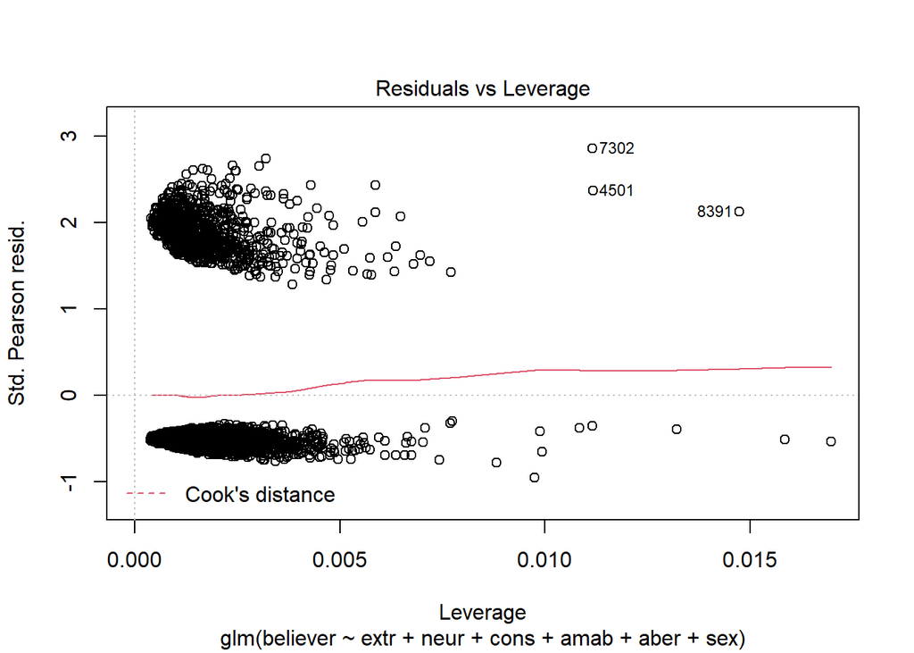

```r
plot(mod_rlog1, which = 5)
```

```r
# verificar se os pontos se concentram dentro dos limites da linha tracejada (cook's distance)

summary(stdres(mod_rlog1))
```

```
##       Min.    1st Qu.     Median       Mean    3rd Qu.       Max.
## -0.9535148 -0.5449730 -0.4939966  0.0000884 -0.4199491  2.8563437
```

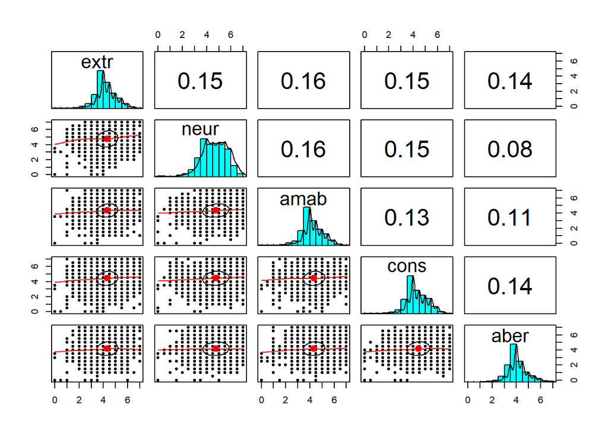

```r
# o resultados deve estar entre -3 e 3.

## 4. Ausência de multicolinearidade
pairs.panels(rwas[,c("extr","neur","amab","cons","aber")])
```

```r
## As correlações devem estar abaixo de 0,9 (alguns autores falam em <0.8)

vif(mod_rlog1)
```

```
##     extr     neur     cons     amab     aber      sex
## 1.047585 1.045897 1.045920 1.043189 1.030744 1.008356
```

```r
## ocorre problema de multicolinearidade quanto vif>10
```